# USASK Data Science Bootcamp T6: Statistical Machine Learning Ridge, Lasso, Elastic Net R Tutorial

TA: Kyle Gardiner Tutors: Lina Li and Jing Wang

June 13, 2023. (3:50pm-4:30pm)

This document will outline how to employ Ridge regression, Lasso Regression, and Elastic Net.

First we will load in the necessary packages for this tutorial.

```r
rm(list=ls(all=TRUE)) # removes objects from the environment to start fresh

library(ISLR2) # contains the dataset "Auto" used in this tutorial
library(glmnet) # used for ridge, lasso, and elastic net
library(caret) # used for elastic net
```

We will be using the same dataset for all 3 methods so lets load in the data and split it before going into each of the methods.

#### Loading in the data

```r
data(Auto) # adds the "Auto" dataset to the environment

?Auto # Prints dataframe information in the 'help' console

str(Auto) # Displays the structure of the "Auto" dataset
```

```
## 'data.frame':    392 obs. of  9 variables:
##  $ mpg         : num  18 15 18 16 17 15 14 14 14 15 ...
##  $ cylinders   : int  8 8 8 8 8 8 8 8 8 8 ...
##  $ displacement: num  307 350 318 304 302 429 454 440 455 390 ...
##  $ horsepower  : int  130 165 150 150 140 198 220 215 225 190 ...
##  $ weight      : int  3504 3693 3436 3433 3449 4341 4354 4312 4425 3850 ...
##  $ acceleration: num  12 11.5 11 12 10.5 10 9 8.5 10 8.5 ...
##  $ year        : int  70 70 70 70 70 70 70 70 70 70 ...
##  $ origin      : int  1 1 1 1 1 1 1 1 1 1 ...
##  $ name        : Factor w/ 304 levels "amc ambassador brougham",..: 49 36 231 14 161 141 54 223 241 2 ...
##  - attr(*, "na.action")= 'omit' Named int [1:5] 33 127 331 337 355
##   ..- attr(*, "names")= chr [1:5] "33" "127" "331" "337" ...
```

```r
dim(Auto) # Displays the dimensions of the "Auto" dataset (rows x columns)
```

```
## [1] 392   9
```

```r
sum(is.na(Auto)) # checking for missing values that might need to be dealt with before data analysis
```

```
## [1] 0
```

#### Formatting data

Before we start building the model, we need to do some data formatting that will help us in the later sections.

```r
# need to convert categorical variables to factors
Auto$cylinders<-as.factor(Auto$cylinders)
Auto$year<-as.factor(Auto$year)
Auto$origin<-as.factor(Auto$origin)

# using 'model.matrix()' to create a design matrix
xx <- model.matrix(mpg ~., Auto[,-9]) # using all the predictors except for 'name'
yy <- Auto$mpg # defining the outcome variable; 'mpg'

# specifying grid to be used later in the functions
grid<-10^seq(10, -2, length=100)
```

#### Splitting the Data

```r
set.seed(1) # set the seed for reproducibility
id<-sample(nrow(Auto),round(nrow(Auto)*0.80)) # Used to identify indexes that fall in train or test
xx.train<-xx[id,]# 'xx.train' contains 80% of the original data for predictors
xx.test<-xx[-id,]# 'xx.test' contains the remaining 20% of the original data for predictors
yy.train<-yy[id]# 'yy.train' contains 80% of the original data for outcome
yy.test<-yy[-id]# 'yy.test' contains the remaining 20% of the original data for outcome
```

Once we have finished loading, formatting, and splitting the data, we can start with ridge regression.

## Ridge Regression

#### $(a)$ Ridge Regression Model Building

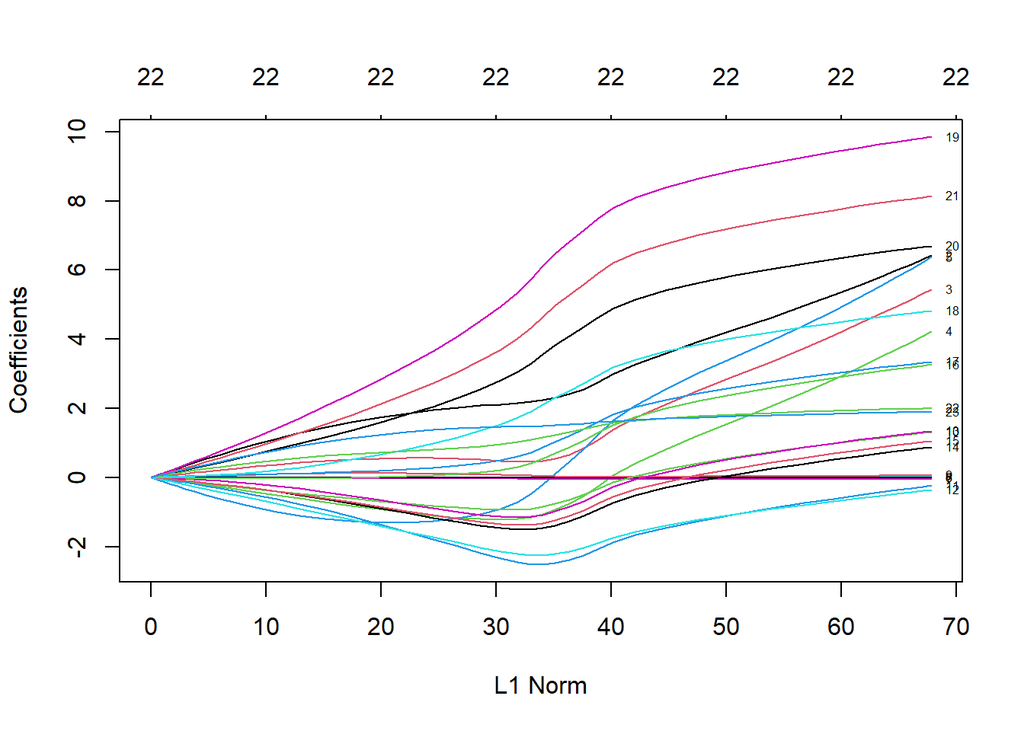

```r
# To fit the ridge regression model, we use the 'glmnet()' function from the glmnet package
ridge.mod <- glmnet(xx.train, yy.train, alpha = 0, lambda = grid) # IMPORTANT: specifying 'alpha' is necessary to apply the proper regularization penalty to the model
                                                                  # 'alpha=0' specifies ridge regression
plot(ridge.mod, label = T) # plot to visualize how the coefficient estimates change as the shrinkage penalty changes
```

#### $(b)$ Cross Validation to identify best $\lambda$ that reduces error

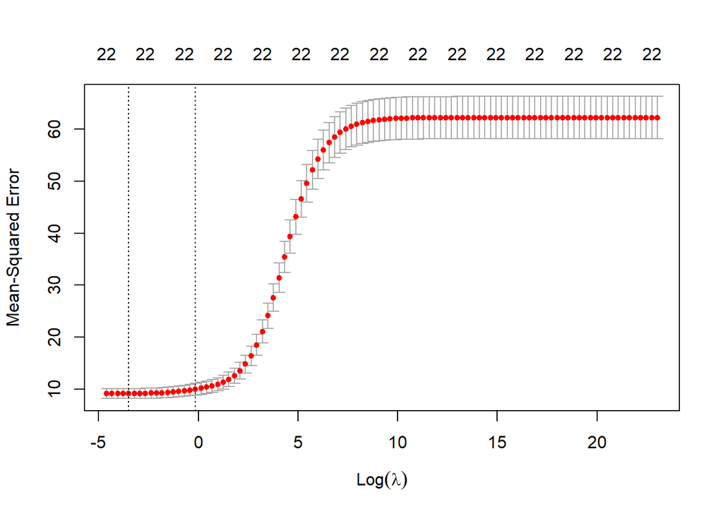

```r
ridge.cv <- cv.glmnet(xx.train, yy.train, alpha = 0, lambda = grid, nfolds=10) # 10 fold cross validation

plot(ridge.cv) # plot to visualize how MSE changes as lambda changes
```

#### $(c)$ Assessing model accuracy

```r
bestlam.ridge <- ridge.cv$lambda.1se # can either use 'lambda.min' or 'lambda.1se'

ridge.pred=predict(ridge.mod, s=bestlam.ridge, newx=xx.test) # predicting the values using the non-cv ridge model and the best lambda from cross validation

mean((ridge.pred-yy.test)^2) # calculating mean squared error for this model
```

```
## [1] 7.698884
```

We will compare the accuracy of these models at the very end.